# Trabajo Final — Solicitudes de crédito

Solicitudes de crédito: ¿qué determina el monto pedido y quién termina siendo mal pagador?

**Trabajo Final — Taller de Pre-procesamiento de Datos**

Licenciatura en Ciencia de Datos · Universidad Austral

Exequiel Cortesi Neri · Gregorio Fernández Perrier

26 de noviembre de 2026

## Datos y objetivos

- Fuente: base `credit_data` del paquete `modeldata` de R
- **4454 solicitudes** de crédito de consumo y **14 variables**
- Perfil del solicitante, condiciones del préstamo y resultado (bueno / malo)

Objetivo 1 · Regresión lineal

¿De qué depende el **monto pedido** (`Amount`)?

Objetivo 2 · Regresión logística

¿Quién termina siendo **mal pagador**? (28 % de malos)

## Pre-procesamiento: las 6 técnicas

| Técnica | Qué hicimos | Por qué |
| --- | --- | --- |
| **Datos faltantes** | Imputación kNN (k = 5) | No son al azar: borrar casos sesga |
| **Recodificación** | Agrupamos categorías chicas; referencia = la más frecuente | Coeficientes estables e interpretables |
| **Variables derivadas** | `Ingreso_faltante`, `Pct_fin`, `Tiene_deuda` | Conservar y resumir información útil |
| **Transformaciones** | log en monto, precio e ingreso; log(1 + x) en activos y antigüedad (esta, en la logística) | Reducir asimetría y efectos no lineales |
| **Cambio de escala** | No estandarizamos | Interpretar en años, meses y % |
| **Valores atípicos** | No eliminamos ninguno | Son casos reales; medimos su influencia |

## Faltantes (1): ¿por qué falta el ingreso?

`Income` falta en **381 casos (8,6 %)**

| Medida | Ingreso observado | Ingreso faltante |
| --- | --- | --- |
| % mal pagadores | 25,5 | 57,0 |
| % con empleo fijo | 68,0 | 9,2 |
| % con antecedentes | 16,4 | 27,8 |
| Antigüedad (mediana, años) | 5,0 | 3,0 |

- Regresión logística de `Ingreso_faltante` sobre `Status` vs. modelo nulo: `lrtest`, **p <0,001**
- **No es MCAR:** la ausencia se relaciona con otras variables
- **Plausible MAR:** se asocia con variables que observamos
- **MNAR no es verificable** con estos datos

## Faltantes (2): qué hicimos

- **No borrar casos** (sesga y pierde 9,3 % de las filas) **ni usar la mediana**
- **kNN (k = 5)** con variables completas: antigüedad, edad, plazo, gastos, precio y antecedentes
- Sin `Status` ni `Amount`: no metemos las respuestas
- **`Ingreso_faltante`**: marca creada **antes** de imputar

| Ingreso | n | Media | Desvío | Mediana | Mín. | Máx. |
| --- | --- | --- | --- | --- | --- | --- |
| Observados | 4073 | 141,7 | 80,7 | 125 | 6 | 959 |
| Imputados (kNN) | 381 | 126,6 | 38,1 | 123 | 45 | 310 |
| Imputados (mediana) | 381 | 125,0 | 0,0 | 125 | 125 | 125 |

## Transformaciones y valores atípicos

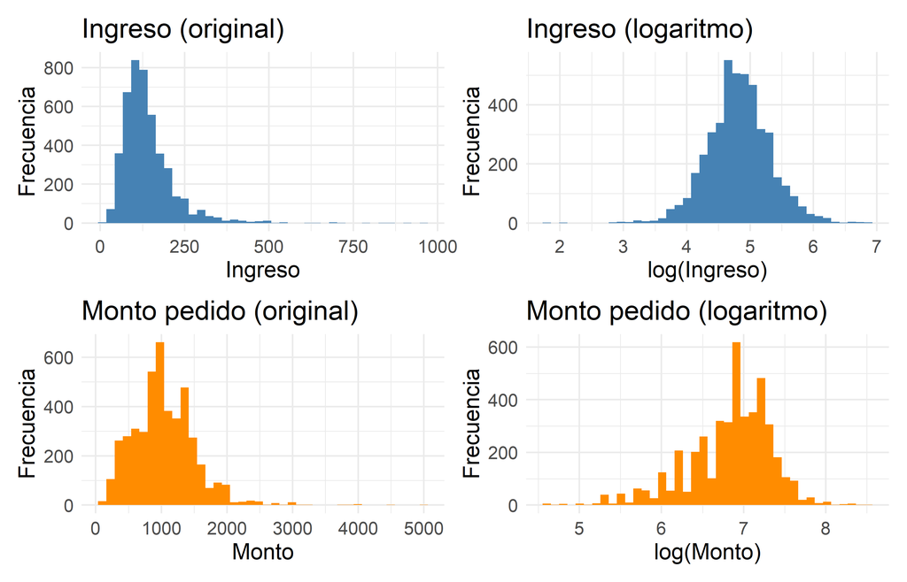

Atípicos (regla del boxplot)

| Variable | Original | Con log |
| --- | --- | --- |
| Price | 174 | 274 |
| Income | 232 | 101 |
| Assets | 278 | 0 |

- El **log** acerca la cola larga al resto
- En `Price` aparecen precios bajos como atípicos
- **No eliminamos casos:** son plausibles, no errores

## Exploratorio: el monto pedido

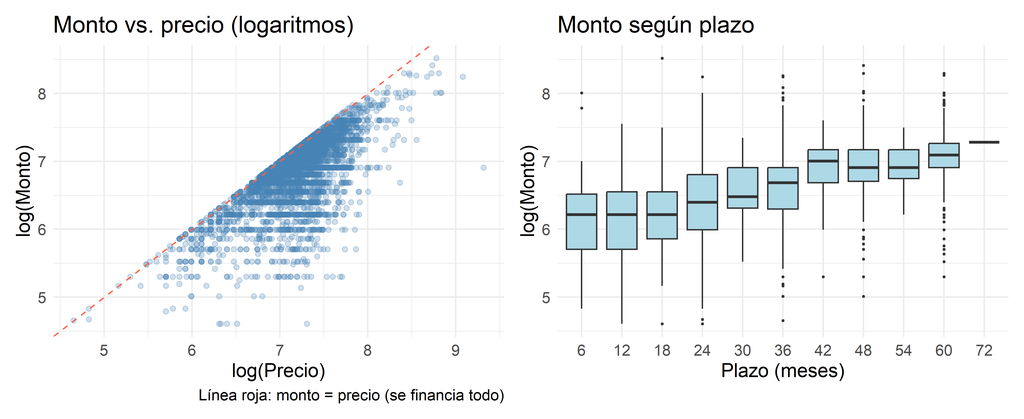

- Correlación de log(monto) con log(precio): **0,71**; ningún monto supera el precio
- Correlación de log(monto) con el plazo: **0,53**; el aumento se desacelera

## Exploratorio: ¿quién es mal pagador?

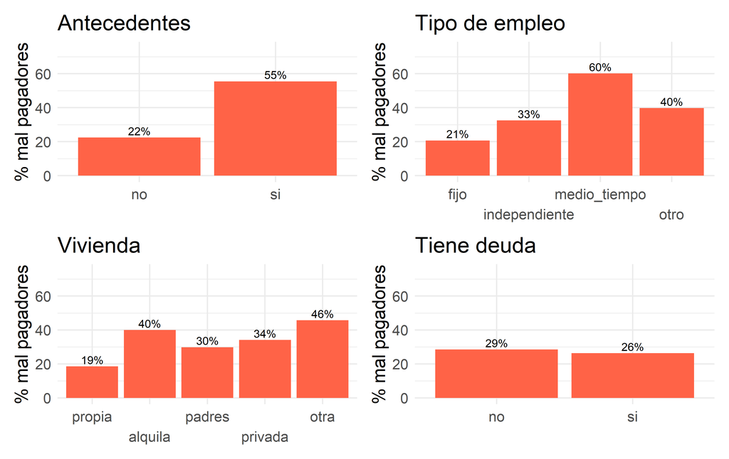

- **Antecedentes:** 55 % vs. 22 % sin ellos
- **Medio tiempo** 60 % e **independientes** 33 % vs. fijo 21 %
- **Propietarios** 19 % vs. alquiler 40 %
- **Deuda previa:** casi no cambia (26 % con deuda vs. 29 % sin)

## Modelo lineal: selección de variables

Respuesta: log(monto) · Selección hacia atrás (*backward*) con `stepAIC`

| Modelo | Coeficientes | AIC | BIC | R² ajustado |
| --- | --- | --- | --- | --- |
| Completo | 20 | -10736,6 | -10608,6 | 0,6555 |
| Backward (AIC) | 19 | -10738,5 | -10616,8 | 0,6555 |
| Backward (BIC) | 10 | -10721,5 | -10657,5 | 0,6535 |

- **AIC** solo descarta `Ingreso_faltante`
- **BIC deja 7 variables:** precio, plazo, antigüedad, antecedentes, empleo, ingreso y deuda
- R² ajustado: **0,6555 → 0,6535** (elegimos BIC por parsimonia)
- **Sin multicolinealidad:** GVIF ajustado < 1,8

## Modelo lineal: supuestos

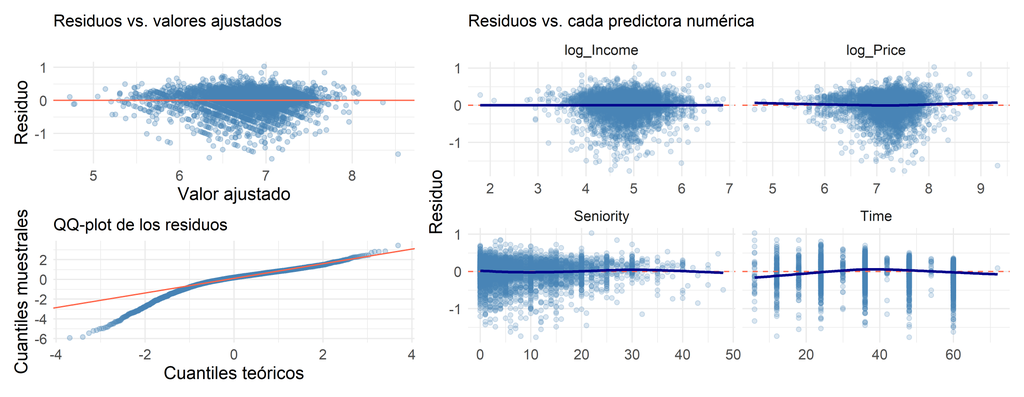

- **Breusch-Pagan** (p <0,001) y **Anderson-Darling** (p <0,001) rechazan
- **`Time` tiene curvatura** → agregamos **Time²** (el BIC mejora 87 puntos)
- Con Time² **persisten** heterocedasticidad y no normalidad → bootstrap

## Modelo lineal: influyentes y bootstrap

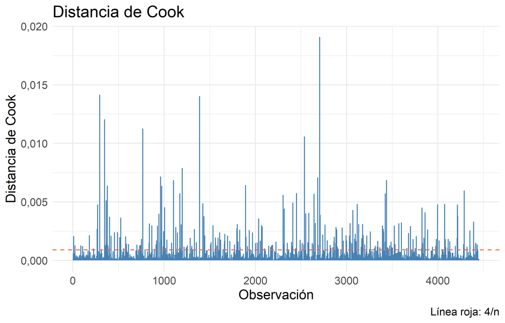

- **Cook máximo 0,019** (lejos de 1): ningún caso domina
- Son casos reales: **no se eliminan**
- **Bootstrap:** 1000 remuestras de filas
- Ancho de los IC: **1,00 veces** el clásico (mediana) → **inferencia confiable**

## Modelo lineal final

R² ajustado: 0,661 · Elasticidad del precio: 0,74 (+10 % en el precio → **+7,3 %** de monto)

**Plazo** (respecto de 12 meses)

| Plazo | Cambio en el monto |
| --- | --- |
| 24 meses | +32 % |
| 36 meses | +64,2 % |
| 48 meses | +92,5 % |
| 60 meses | +112,6 % |

**Perfil** (a igualdad del resto)

- **Antecedentes:** +4,1 %
- **Empleo** (vs. fijo): independiente +9 %, medio tiempo +5,8 %, otro +5,4 %
- **Ingreso** +10 % → monto +0,7 %
- **Deuda previa:** −3,8 %

## Logística: cómo se armó el modelo

- **Partición 75/25 antes de imputar:** si no, datos de prueba se filtran al entrenamiento (*fuga de información*) y la evaluación sale optimista
- **Selección con BIC**, solo con *train*: **12 variables**
- **log(1 + Seniority):** Hosmer-Lemeshow pasa de p 0,024 a **p 0,55**
- **`Ingreso_faltante` mejora el ajuste:** `lrtest`, p <0,001

| Versión (train) | AIC | BIC | p Hosmer-Lemeshow |
| --- | --- | --- | --- |
| Seniority lineal | 2817,8 | 2934,0 | 0,024 |
| log(1 + Seniority) (final) | 2808,0 | 2924,1 | 0,550 |

## Logística: odds ratios

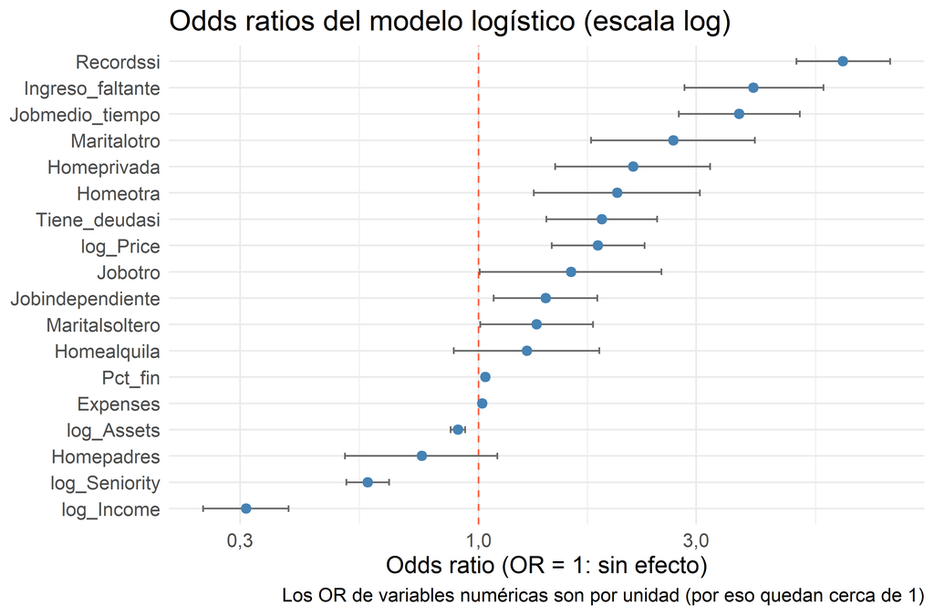

- **Antecedentes:** 6,29
- **Ingreso no informado:** 4,01
- **Medio tiempo** (vs. fijo): 3,72
- **Duplicar el ingreso:** 0,44
- **Duplicar (1 + antigüedad):** 0,68

OR > 1 sube las chances de ser mal pagador; OR < 1 las baja.

## Capacidad predictiva, síntesis y limitaciones

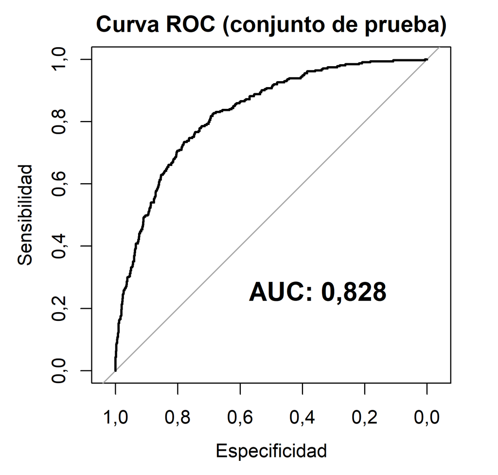

**AUC 0,828** en prueba · Corte **0,27** (`coords` “best”, Youden, en *train*)

| Métrica (prueba) | Corte 0,5 | Corte 0,27 |
| --- | --- | --- |
| Exactitud | 0,785 | 0,754 |
| Sensibilidad | 0,505 | 0,748 |
| Especificidad | 0,895 | 0,756 |
| VPP | 0,653 | 0,545 |
| VPN | 0,822 | 0,885 |
| F1 | 0,569 | 0,631 |

**Conclusiones**

- Monto: sobre todo **precio** y **plazo**
- Más riesgo: **antecedentes**, medio tiempo, ingreso no informado; menos con ingreso y antigüedad
- Buena discriminación; el corte 0,27 detecta **75 %** de los malos

**Limitaciones**

- **MNAR** no se puede verificar
- Son **asociaciones**, no efectos causales
- El **monto está acotado por el precio** (residuos asimétricos)